# Final

### Intro

I would like to investigate if there is a way to predict a movie’s rating based on several attributes about the movie. To do this I am going to use data about IMDb’s 1000 top ranked movies.

We could scrape all the data from IMDB’s website, however, we can download a table with some of the data we want [here](https://www.imdb.com/list/ls053900011/?sort=list_order,asc&st_dt=&mode=detail&page=1&ref_=ttls_vm_dtl), and can supplement that data with two other sets from Kaggle [here](https://www.kaggle.com/pkabir/imdb-movie-ratings/data#) [and here](https://www.kaggle.com/stefanoleone992/imdb-extensive-dataset?select=IMDb+movies.csv). This is the preferred option for me so I will download all three of those in Comma-Separated-Value (CSV) format.

### Tidying Data

#### Loading Data

In order to manipulate this data in R, we will use the command read_csv() to first load it into an R dataframe.

```r
library(tidyverse)
from_website <- read_csv("~/downloads/Imdb top 1000 list.csv")
head(from_website)
```

| Position | Const | Created | Modified | Description | Title | URL | Title Type | IMDb Rating | Runtime (mins) | Year | Genres | Num Votes | Release Date | Directors |
| --- | --- | --- | --- | --- | --- | --- | --- | --- | --- | --- | --- | --- | --- | --- |
| 1 | tt0111161 | 2013-07-06 | 2013-07-06 | NA | The Shawshank Redemption | https://www.imdb.com/title/tt0111161/ | movie | 9.3 | 142 | 1994 | Drama | 2239868 | 1994-09-10 | Frank Darabont |
| 2 | tt0068646 | 2013-07-06 | 2013-07-06 | NA | The Godfather | https://www.imdb.com/title/tt0068646/ | movie | 9.2 | 175 | 1972 | Crime, Drama | 1544724 | 1972-03-14 | Francis Ford Coppola |
| 3 | tt0071562 | 2013-07-06 | 2013-07-06 | NA | The Godfather: Part II | https://www.imdb.com/title/tt0071562/ | movie | 9.0 | 202 | 1974 | Crime, Drama | 1080234 | 1974-12-12 | Francis Ford Coppola |
| 4 | tt0468569 | 2013-07-06 | 2013-07-06 | NA | The Dark Knight | https://www.imdb.com/title/tt0468569/ | movie | 9.0 | 152 | 2008 | Action, Crime, Drama, Thriller | 2209690 | 2008-07-14 | Christopher Nolan |
| 5 | tt0110912 | 2013-07-06 | 2013-07-06 | NA | Pulp Fiction | https://www.imdb.com/title/tt0110912/ | movie | 8.9 | 154 | 1994 | Crime, Drama | 1754864 | 1994-05-21 | Quentin Tarantino |
| 6 | tt0060196 | 2013-07-06 | 2013-07-06 | NA | Il buono, il brutto, il cattivo | https://www.imdb.com/title/tt0060196/ | movie | 8.8 | 161 | 1966 | Western | 661719 | 1966-12-23 | Sergio Leone |

```r
with_ratings <- read_csv("~/downloads/imdb_1000.csv")
head(with_ratings)
```

| star_rating | title | content_rating | genre | duration | actors_list |
| --- | --- | --- | --- | --- | --- |
| 9.3 | The Shawshank Redemption | R | Crime | 142 | [u'Tim Robbins', u'Morgan Freeman', u'Bob Gunton'] |
| 9.2 | The Godfather | R | Crime | 175 | [u'Marlon Brando', u'Al Pacino', u'James Caan'] |
| 9.1 | The Godfather: Part II | R | Crime | 200 | [u'Al Pacino', u'Robert De Niro', u'Robert Duvall'] |
| 9.0 | The Dark Knight | PG-13 | Action | 152 | [u'Christian Bale', u'Heath Ledger', u'Aaron Eckhart'] |
| 8.9 | Pulp Fiction | R | Crime | 154 | [u'John Travolta', u'Uma Thurman', u'Samuel L. Jackson'] |
| 8.9 | 12 Angry Men | NOT RATED | Drama | 96 | [u'Henry Fonda', u'Lee J. Cobb', u'Martin Balsam'] |

```r
with_budget <- read_csv("~/downloads/IMDB movies.csv")
head(with_budget)
```

| imdb_title_id | title | original_title | year | date_published | genre | duration | country | language | director | writer | production_company | actors | description | avg_vote | votes | budget | usa_gross_income | worlwide_gross_income | metascore | reviews_from_users | reviews_from_critics |
| --- | --- | --- | --- | --- | --- | --- | --- | --- | --- | --- | --- | --- | --- | --- | --- | --- | --- | --- | --- | --- | --- |
| tt0000574 | The Story of the Kelly Gang | The Story of the Kelly Gang | 1906 | 1906-12-26 | Biography, Crime, Drama | 70 | Australia | NA | Charles Tait | Charles Tait | J. and N. Tait | Elizabeth Tait, John Tait, Norman Campbell, Bella Cola, Will Coyne, Sam Crewes, Jack Ennis, John Forde, Vera Linden, Mr. Marshall, Mr. McKenzie, Frank Mills, Ollie Wilson | True story of notorious Australian outlaw Ned Kelly (1855-80). | 6.1 | 537 | $ 2250 | NA | NA | NA | 7 | 7 |
| tt0001892 | Den sorte drøm | Den sorte drøm | 1911 | 1911-08-19 | Drama | 53 | Germany, Denmark | NA | Urban Gad | Urban Gad, Gebhard Schätzler-Perasini | Fotorama | Asta Nielsen, Valdemar Psilander, Gunnar Helsengreen, Emil Albes, Hugo Flink, Mary Hagen | Two men of high rank are both wooing the beautiful and famous equestrian acrobat Stella. While Stella ignores the jeweler Hirsch, she accepts Count von Waldberg's offer to follow her home, ... | 5.9 | 171 | NA | NA | NA | NA | 4 | 2 |
| tt0002101 | Cleopatra | Cleopatra | 1912 | 1912-11-13 | Drama, History | 100 | USA | English | Charles L. Gaskill | Victorien Sardou | Helen Gardner Picture Players | Helen Gardner, Pearl Sindelar, Miss Fielding, Miss Robson, Helene Costello, Charles Sindelar, Mr. Howard, James R. Waite, Mr. Osborne, Harry Knowles, Mr. Paul, Mr. Brady, Mr. Corker | The fabled queen of Egypt's affair with Roman general Marc Antony is ulimately disastrous for both of them. | 5.2 | 420 | $ 45000 | NA | NA | NA | 24 | 3 |
| tt0002130 | L'Inferno | L'Inferno | 1911 | 1911-03-06 | Adventure, Drama, Fantasy | 68 | Italy | Italian | Francesco Bertolini, Adolfo Padovan | Dante Alighieri | Milano Film | Salvatore Papa, Arturo Pirovano, Giuseppe de Liguoro, Pier Delle Vigne, Augusto Milla, Attilio Motta, Emilise Beretta | Loosely adapted from Dante's Divine Comedy and inspired by the illustrations of Gustav Doré the original silent film has been restored and has a new score by Tangerine Dream. | 7.0 | 2019 | NA | NA | NA | NA | 28 | 14 |
| tt0002199 | From the Manger to the Cross; or, Jesus of Nazareth | From the Manger to the Cross; or, Jesus of Nazareth | 1912 | 1913 | Biography, Drama | 60 | USA | English | Sidney Olcott | Gene Gauntier | Kalem Company | R. Henderson Bland, Percy Dyer, Gene Gauntier, Alice Hollister, Samuel Morgan, James D. Ainsley, Robert G. Vignola, George Kellog, J.P. McGowan | An account of the life of Jesus Christ, based on the books of the New Testament: After Jesus' birth is foretold to his parents, he is born in Bethlehem, and is visited by shepherds and wise... | 5.7 | 438 | NA | NA | NA | NA | 12 | 5 |
| tt0002423 | Madame DuBarry | Madame DuBarry | 1919 | 1919-11-26 | Biography, Drama, Romance | 85 | Germany | German | Ernst Lubitsch | Norbert Falk, Hanns Kräly | Projektions-AG Union (PAGU) | Pola Negri, Emil Jannings, Harry Liedtke, Eduard von Winterstein, Reinhold Schünzel, Else Berna, Fred Immler, Gustav Czimeg, Karl Platen, Bernhard Goetzke, Magnus Stifter, Paul Biensfeldt, Willy Kaise… | The story of Madame DuBarry, the mistress of Louis XV of France, and her loves in the time of the French revolution. | 6.8 | 709 | NA | NA | NA | NA | 11 | 9 |

#### Cleaning Data

Now that we have all of our tables, we can start cleaning up the data to make it easier to manipulate and more relevant for our purposes.

Starting with the table from IMDB’s website. We can eliminate the columns Position, Created and Modified (they’re relevant to the postings, not the movies), Description (it’s empty), URL (it’s unnecessary for our purposes), Title Type (they’re all movies), Year (the year is included in release date), and Number of Votes (while it might be a good statistic for estimating purposes, we don’t have the number of people who participated in total). I chose to specify the columns using their indices but you can use their names as well. We will also format ‘Release Date’ as a date object.

```r
library (lubridate)
from_website <- from_website %>% select(2,6,9,10,14,15)
from_website$`Release Date` <- as_date(from_website$`Release Date`)
head(from_website)
```

| Const | Title | IMDb Rating | Runtime (mins) | Release Date | Directors |
| --- | --- | --- | --- | --- | --- |
| tt0111161 | The Shawshank Redemption | 9.3 | 142 | 1994-09-10 | Frank Darabont |
| tt0068646 | The Godfather | 9.2 | 175 | 1972-03-14 | Francis Ford Coppola |
| tt0071562 | The Godfather: Part II | 9.0 | 202 | 1974-12-12 | Francis Ford Coppola |
| tt0468569 | The Dark Knight | 9.0 | 152 | 2008-07-14 | Christopher Nolan |
| tt0110912 | Pulp Fiction | 8.9 | 154 | 1994-05-21 | Quentin Tarantino |
| tt0060196 | Il buono, il brutto, il cattivo | 8.8 | 161 | 1966-12-23 | Sergio Leone |

For the table with ratings, we only want the content ratings, genre, and title (which we’ll use to join the tables soon).

```r
with_ratings <- with_ratings %>% select(2,3,4)
head(with_ratings)
```

| title | content_rating | genre |
| --- | --- | --- |
| The Shawshank Redemption | R | Crime |
| The Godfather | R | Crime |
| The Godfather: Part II | R | Crime |
| The Dark Knight | PG-13 | Action |
| Pulp Fiction | R | Crime |
| 12 Angry Men | NOT RATED | Drama |

And for the table with the budget we want the ID (again used for merging the tables), writer, production company, and budget. This table requires a little extra clean up.

```r
with_budget <- with_budget %>% select(1,11,12,17)
head(with_budget)
```

| imdb_title_id | writer | production_company | budget |
| --- | --- | --- | --- |
| tt0000574 | Charles Tait | J. and N. Tait | $ 2250 |
| tt0001892 | Urban Gad, Gebhard Schätzler-Perasini | Fotorama | NA |
| tt0002101 | Victorien Sardou | Helen Gardner Picture Players | $ 45000 |
| tt0002130 | Dante Alighieri | Milano Film | NA |
| tt0002199 | Gene Gauntier | Kalem Company | NA |
| tt0002423 | Norbert Falk, Hanns Kräly | Projektions-AG Union (PAGU) | NA |

#### Creating the Master Table

Now that we have all the attributes we want across 3 tables, we can combine them into one table using a join function. We want only data on the movies from IMDB’s table, so we will use a left join.

```r
master_tab <- from_website %>% left_join(with_ratings, by=c("Title" = "title"))
master_tab <- master_tab %>% left_join(with_budget, by=c("Const" = "imdb_title_id"))
head(master_tab)
```

| Const | Title | IMDb Rating | Runtime (mins) | Release Date | Directors | content_rating | genre | writer | production_company | budget |
| --- | --- | --- | --- | --- | --- | --- | --- | --- | --- | --- |
| tt0111161 | The Shawshank Redemption | 9.3 | 142 | 1994-09-10 | Frank Darabont | R | Crime | Stephen King, Frank Darabont | Castle Rock Entertainment | $ 25000000 |
| tt0068646 | The Godfather | 9.2 | 175 | 1972-03-14 | Francis Ford Coppola | R | Crime | Mario Puzo, Francis Ford Coppola | Paramount Pictures | $ 6000000 |
| tt0071562 | The Godfather: Part II | 9.0 | 202 | 1974-12-12 | Francis Ford Coppola | R | Crime | Francis Ford Coppola, Mario Puzo | Paramount Pictures | $ 13000000 |
| tt0468569 | The Dark Knight | 9.0 | 152 | 2008-07-14 | Christopher Nolan | PG-13 | Action | Jonathan Nolan, Christopher Nolan | Warner Bros. | $ 185000000 |
| tt0110912 | Pulp Fiction | 8.9 | 154 | 1994-05-21 | Quentin Tarantino | R | Crime | Quentin Tarantino, Roger Avary | Miramax | $ 8000000 |
| tt0060196 | Il buono, il brutto, il cattivo | 8.8 | 161 | 1966-12-23 | Sergio Leone | NA | NA | Luciano Vincenzoni, Sergio Leone | Produzioni Europee Associate (PEA) | $ 1200000 |

### Attributes

Const - this is IMDb’s id for the movie (character) Title - the title of the movie (character) IMDb Rating - the rating of the movie on a scale of 0 to 10 stars (numeric) Runtime - the runtime of the movie in minutes (numeric) Release Date - the date the movie was released (yyyy-mm-dd) (datetime) Directors - the movie’s director(s) (character) Content Rating - the rating as decided by the Motion Picture Association of America concerning suitability of the film’s content (character) Genre - the genre of the movie according to IMDb (character) Writer - the writer of the movie (character) Production Company - the company that produced the movie (character) Budget - the production budget for the movie (character) Season (to be added) - the season during which the movie was released (character)

### Exploratory Data Analysis

Now that we have our data, we can create visuals to better see the spread and trends in our data. We will mainly utilize ggplot to create these visuals.

### Runtime

We will make a scatter plot of runtime vs rating.

[figure not shown]

```r
master_tab %>% ggplot(aes(x=master_tab$`Runtime (mins)`, y=master_tab$`IMDb Rating`)) + geom_point() + labs(x="runtime (mins)", y="IMDb Rating")
```

There may be a trend between these two that we will further investigate later.

### Season

We want to look at the relationship between release date and rating, so we can start by categorizing the release dates into seasons. We will add a new atrribute to our table for this value.

```r
get_season <- function(date) {
  m <- month(date)
  if (m == 12 || m == 1 | m == 2)
    "Winter"
  else if (m >= 3 && m <= 5)
    "Spring"
  else if (m >= 6 && m <= 8)
    "Summer"
  else
    "Fall"
}

master_tab <- master_tab %>% mutate(season = sapply(master_tab$`Release Date`, get_season))
head(master_tab)
```

| Const | Title | IMDb Rating | Runtime (mins) | Release Date | Directors | content_rating | genre | writer | production_company | budget | season |
| --- | --- | --- | --- | --- | --- | --- | --- | --- | --- | --- | --- |
| tt0111161 | The Shawshank Redemption | 9.3 | 142 | 1994-09-10 | Frank Darabont | R | Crime | Stephen King, Frank Darabont | Castle Rock Entertainment | $ 25000000 | Fall |
| tt0068646 | The Godfather | 9.2 | 175 | 1972-03-14 | Francis Ford Coppola | R | Crime | Mario Puzo, Francis Ford Coppola | Paramount Pictures | $ 6000000 | Spring |
| tt0071562 | The Godfather: Part II | 9.0 | 202 | 1974-12-12 | Francis Ford Coppola | R | Crime | Francis Ford Coppola, Mario Puzo | Paramount Pictures | $ 13000000 | Winter |
| tt0468569 | The Dark Knight | 9.0 | 152 | 2008-07-14 | Christopher Nolan | PG-13 | Action | Jonathan Nolan, Christopher Nolan | Warner Bros. | $ 185000000 | Summer |
| tt0110912 | Pulp Fiction | 8.9 | 154 | 1994-05-21 | Quentin Tarantino | R | Crime | Quentin Tarantino, Roger Avary | Miramax | $ 8000000 | Spring |
| tt0060196 | Il buono, il brutto, il cattivo | 8.8 | 161 | 1966-12-23 | Sergio Leone | NA | NA | Luciano Vincenzoni, Sergio Leone | Produzioni Europee Associate (PEA) | $ 1200000 | Winter |

Then we will create boxplots for ratings conditioned on season.

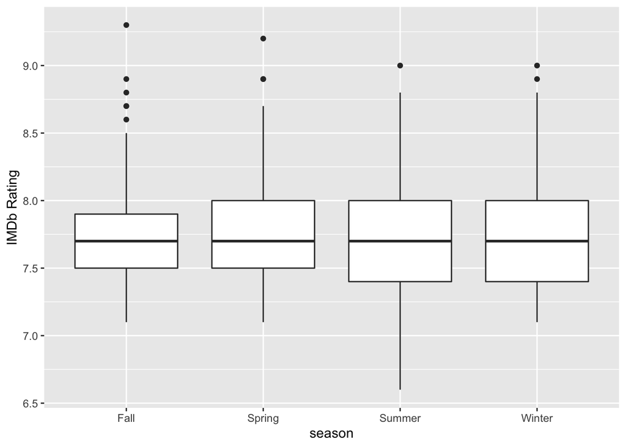

```r
master_tab %>% ggplot(aes(x=master_tab$season, y=master_tab$`IMDb Rating`)) + geom_boxplot() + labs(x="season", y="IMDb Rating")
```

These plots all seem centered around the same rating and have similar distributions, although summer does seem to have a lower minimum than the other 3 seasons.

### Content Rating

We will also create boxplots to visualize the distribution of the content ratings vs movie ratings.

[figure not shown]

```r
master_tab %>% ggplot(aes(x=master_tab$content_rating.x, y=master_tab$`IMDb Rating`)) + geom_boxplot() + labs(x="Content Rating", y="IMDb Rating")
```

### Genre

We will make one more boxplot for ratings conditioned on genre.

[figure not shown]

```r
master_tab %>% ggplot(aes(x=master_tab$genre.y, y=master_tab$`IMDb Rating`)) + geom_boxplot() + labs(x="Genre", y="IMDb Rating")
```

### Budget

[figure not shown]

```r
master_tab %>% filter(substring(master_tab$budget, 0, 1) == "$") %>% mutate(numeric_budget = substr(budget, 2, 100)) %>% mutate(numeric_budget = as.numeric(numeric_budget)) %>% ggplot(aes(x=numeric_budget, y=`IMDb Rating`)) + geom_point() + labs(x="Budget", y="IMDb Rating")
```

There seems to be an interesting trend of fewer extreme ratings as budget increases. We can investigate this futher later.

### Linear Regression

Now that we’ve visualize the relationships between ratings and our other attributes, we can try to find a mathematical relationship between them. The two most interesting categories seemed to be run time and budget, so we will create our regression with those.

```r
library(ISLR)
library(broom)

fit_tab <- master_tab %>% filter(substring(master_tab$budget, 0, 1) == "$") %>% mutate(numeric_budget = substr(budget, 2, 100)) %>% mutate(numeric_budget = as.numeric(numeric_budget))
fit <- lm(fit_tab$`IMDb Rating`~1+fit_tab$numeric_budget+fit_tab$`Runtime (mins)`, data=fit_tab)
fit %>% tidy() %>% knitr::kable()
```

| term | estimate | std.error | statistic | p.value |
| --- | --- | --- | --- | --- |
| (Intercept) | 7.2453040 | 0.0619616 | 116.932213 | 0.00e+00 |
| fit_tab$numeric_budget | 0.0000000 | 0.0000000 | -4.252653 | 2.35e-05 |
| fit_tab$`Runtime (mins)` | 0.0044425 | 0.0005181 | 8.574926 | 0.00e+00 |

### Resources

We used several libraries during our exploration. There are many more applications of these libraries than just the ones we used today, so below are links to more information about each of the libraries for further information.

[tidyverse](https://www.tidyverse.org) [ggplot](https://ggplot2.tidyverse.org) is part of tidyverse, but here is more information specifically about ggplot [lubridate](https://lubridate.tidyverse.org) also a part of tidyverse [ISLR](https://cran.r-project.org/web/packages/ISLR/ISLR.pdf) [broom](https://cran.r-project.org/web/packages/broom/vignettes/broom.html)

[Kaggle](https://www.kaggle.com) is a great source for free datasets on a variety of topics